# Problem Set 2

Camila Carrasco

01/13/2018

- Stackoverflow account user: 9174147
- Github id: camilacd

for rank: if x is not numeric: as.numeric(x)

wrapping the code makes it to print

http://rpubs.com/anaraldy/161294 https://www.nateday.me/r4ds_exercises.html https://github.com/maxconway/r4ds_solutions/blob/master/transform_solutions.Rmd https://github.com/cimentadaj/R4DS-Solutions/blob/master/Ch3.Rmd http://r4ds.had.co.nz/workflow-scripts.html https://www2.stat.duke.edu/courses/Spring16/sta101.001/post/labs/intro_to_data.html

# 1 R for Data Science Exercises

## 1.1 Misc

```r
library(tidyverse)
library(nycflights13)
```

## 1.2 Section 5.6.7

**1. Calculate the number of flights per carrier in reverse alphabetical order**

```r
flights %>%
  group_by(carrier) %>%
  summarise(n = n()) %>%
  arrange(desc(carrier))
```

```
## # A tibble: 16 x 2
##    carrier     n
##      <chr> <int>
##  1      YV   601
##  2      WN 12275
##  3      VX  5162
##  4      US 20536
##  5      UA 58665
##  6      OO    32
##  7      MQ 26397
##  8      HA   342
##  9      FL  3260
## 10      F9   685
## 11      EV 54173
## 12      DL 48110
## 13      B6 54635
## 14      AS   714
## 15      AA 32729
## 16      9E 18460
```

**2. Brainstorm at least 5 different ways to assess the typical delay characteristics of a group of flights. Write the dplyr code which calculates this delay measure separately by airline. It might be helpful to consider the following scenarios**:

```r
delays_summary <- group_by(flights,carrier) %>% summarise(n_flights = n(),
                                                                pct_on_time = sum((arr_time == sched_arr_time)/n_flights, na.rm = TRUE), #on time
                                                                pct_early = sum((arr_time < sched_arr_time)/n_flights, na.rm = TRUE), #early
                                                                pct_late = sum((arr_time > sched_arr_time)/n_flights, na.rm = TRUE), #late
                                                                pct_15m_early = sum(sched_arr_time - arr_time <= 15, na.rm = TRUE)/n_flights,
                                                                pct_15m_late = sum(arr_time - sched_arr_time > 15, na.rm = TRUE)/n_flights,
                                                                pct_20m_early = sum(sched_arr_time - arr_time <= 20, na.rm = TRUE)/n_flights,
                                                                pct_20m_late = sum(arr_time - sched_arr_time > 20, na.rm = TRUE)/n_flights,
                                                                pct_30m_early = sum(sched_arr_time - arr_time <= 30, na.rm = TRUE)/n_flights,
                                                                pct_30m_late = sum(arr_time - sched_arr_time > 30, na.rm = TRUE)/n_flights,
                                                                pct_2h_early = sum(arr_time - sched_arr_time <= 120, na.rm = TRUE)/n_flights,
                                                                pct_2h_late = sum(arr_time - sched_arr_time > 120, na.rm = TRUE)/n_flights)
delays_summary
```

```
## # A tibble: 16 x 13
##    carrier n_flights pct_on_time pct_early  pct_late pct_15m_early
##      <chr>     <int>       <dbl>     <dbl>     <dbl>         <dbl>
##  1      9E     18460 0.012296858 0.5784399 0.3488624     0.5503792
##  2      AA     32729 0.014421461 0.6436188 0.3214886     0.5588622
##  3      AS       714 0.011204482 0.7240896 0.2619048     0.4607843
##  4      B6     54635 0.016948842 0.5734785 0.4004576     0.6908941
##  5      DL     48110 0.016254417 0.6441280 0.3320515     0.6067761
##  6      EV     54173 0.014785963 0.5005446 0.4307312     0.6876857
##  7      F9       685 0.026277372 0.4014599 0.5664234     0.7795620
##  8      FL      3260 0.021165644 0.3892638 0.5653374     0.8168712
##  9      HA       342 0.011695906 0.7076023 0.2807018     0.5058480
## 10      MQ     26397 0.018486949 0.4970262 0.4344433     0.7211426
## 11      OO        32 0.000000000 0.5937500 0.3125000     0.6562500
## 12      UA     58665 0.015648172 0.6076195 0.3639649     0.6271201
## 13      US     20536 0.017968446 0.5920335 0.3562037     0.6595247
## 14      VX      5162 0.018209996 0.6656335 0.3093762     0.5412631
## 15      WN     12275 0.018492872 0.5394705 0.4257434     0.6965377
## 16      YV       601 0.009983361 0.4692180 0.4259567     0.6439268
## # ... with 7 more variables: pct_15m_late <dbl>, pct_20m_early <dbl>,
## #   pct_20m_late <dbl>, pct_30m_early <dbl>, pct_30m_late <dbl>,
## #   pct_2h_early <dbl>, pct_2h_late <dbl>
```

- A flight is 15 minutes early 50% of the time, and 15 minutes late 50% of the time.

```r
delays_summary %>%
  filter(pct_15m_early == 0.5, pct_15m_late == 0.5)
```

```
## # A tibble: 0 x 13
## # ... with 13 variables: carrier <chr>, n_flights <int>,
## #   pct_on_time <dbl>, pct_early <dbl>, pct_late <dbl>,
## #   pct_15m_early <dbl>, pct_15m_late <dbl>, pct_20m_early <dbl>,
## #   pct_20m_late <dbl>, pct_30m_early <dbl>, pct_30m_late <dbl>,
## #   pct_2h_early <dbl>, pct_2h_late <dbl>
```

- A flight is always 20 minutes late.

```r
delays_summary %>%
  filter(pct_20m_late == 1)
```

```
## # A tibble: 0 x 13
## # ... with 13 variables: carrier <chr>, n_flights <int>,
## #   pct_on_time <dbl>, pct_early <dbl>, pct_late <dbl>,
## #   pct_15m_early <dbl>, pct_15m_late <dbl>, pct_20m_early <dbl>,
## #   pct_20m_late <dbl>, pct_30m_early <dbl>, pct_30m_late <dbl>,
## #   pct_2h_early <dbl>, pct_2h_late <dbl>
```

- A flight is 30 minutes early 50% of the time, and 30 minutes late 50% of the time.

```r
delays_summary %>%
  filter(pct_30m_late == 0.5 & pct_30m_early==0.5 )
```

```
## # A tibble: 0 x 13
## # ... with 13 variables: carrier <chr>, n_flights <int>,
## #   pct_on_time <dbl>, pct_early <dbl>, pct_late <dbl>,
## #   pct_15m_early <dbl>, pct_15m_late <dbl>, pct_20m_early <dbl>,
## #   pct_20m_late <dbl>, pct_30m_early <dbl>, pct_30m_late <dbl>,
## #   pct_2h_early <dbl>, pct_2h_late <dbl>
```

- 99% of the time a flight is on time. 1% of the time it’s 2 hours late.

```r
delays_summary %>%
  filter(pct_on_time == 0.99 & pct_2h_late == 0.01)
```

```
## # A tibble: 0 x 13
## # ... with 13 variables: carrier <chr>, n_flights <int>,
## #   pct_on_time <dbl>, pct_early <dbl>, pct_late <dbl>,
## #   pct_15m_early <dbl>, pct_15m_late <dbl>, pct_20m_early <dbl>,
## #   pct_20m_late <dbl>, pct_30m_early <dbl>, pct_30m_late <dbl>,
## #   pct_2h_early <dbl>, pct_2h_late <dbl>
```

**3. Which is more important from a passengers’ perspective: arrival delay or departure delay? Explain why you think this is a better measure. Regardless of your answer, please use arrival delay for the rest of the problem set (so that the TAs can check your answers).**

What matters the most is the arrival delay. Passengers are already at the airport if there is a departure delay, so besides getting bored and anxious, there is no significative cost involved (unless they have to spend the night in an hotel close to the airport). On the other hand, passengers usually have plans and arrangements for the arrival (business meetings, transportation services, accommodations, dinner plans, etc…), that can’t be changed in such short notice.

**4. Come up with another approach that will give you the same output as not_cancelled %>% count(dest) and not_cancelled %>% count(tailnum, wt = distance) (without using count()).**

First approach

```r
not_cancelled <-
  flights %>%
  filter(!is.na(dep_delay), !is.na(arr_delay))

not_cancelled %>%
  count(dest)
```

```
## # A tibble: 104 x 2
##     dest     n
##    <chr> <int>
##  1   ABQ   254
##  2   ACK   264
##  3   ALB   418
##  4   ANC     8
##  5   ATL 16837
##  6   AUS  2411
##  7   AVL   261
##  8   BDL   412
##  9   BGR   358
## 10   BHM   269
## # ... with 94 more rows
```

```r
not_cancelled %>%
  count(tailnum, wt = distance)
```

```
## # A tibble: 4,037 x 2
##    tailnum      n
##      <chr>  <dbl>
##  1  D942DN   3418
##  2  N0EGMQ 239143
##  3  N10156 109664
##  4  N102UW  25722
##  5  N103US  24619
##  6  N104UW  24616
##  7  N10575 139903
##  8  N105UW  23618
##  9  N107US  21677
## 10  N108UW  32070
## # ... with 4,027 more rows
```

Alternative approach

```r
not_cancelled <- filter(flights, !is.na(dep_delay), !is.na(arr_delay))

not_cancelled %>%
  group_by(dest) %>%
  tally()
```

```
## # A tibble: 104 x 2
##     dest     n
##    <chr> <int>
##  1   ABQ   254
##  2   ACK   264
##  3   ALB   418
##  4   ANC     8
##  5   ATL 16837
##  6   AUS  2411
##  7   AVL   261
##  8   BDL   412
##  9   BGR   358
## 10   BHM   269
## # ... with 94 more rows
```

```r
not_cancelled %>%
  group_by(tailnum) %>%
  summarise(n = sum(distance))
```

```
## # A tibble: 4,037 x 2
##    tailnum      n
##      <chr>  <dbl>
##  1  D942DN   3418
##  2  N0EGMQ 239143
##  3  N10156 109664
##  4  N102UW  25722
##  5  N103US  24619
##  6  N104UW  24616
##  7  N10575 139903
##  8  N105UW  23618
##  9  N107US  21677
## 10  N108UW  32070
## # ... with 4,027 more rows
```

**5. Our definition of cancelled flights (is.na(dep_delay) | is.na(arr_delay) ) is slightly suboptimal. Why? Which is the most important column?**

If we’re focusing on the arrivals only, this definition would consider also the flights that have a missing value for the departure delay and not the arrival.

Going further, it can be the case, where one of the variables is missing but the flight is not cancelled. From the combinations between departed and arrived, we can observe that some flights departed but they don’t have data for their arrival (1175), maybe they were re-routed. For the contrary, there are no flights that have data for their arrival but no departure.

```r
flights %>%
    group_by(not_departed = is.na(dep_delay), not_arrived = is.na(arr_delay)) %>%
    summarise(n=n())
```

```
## # A tibble: 3 x 3
## # Groups:   not_departed [?]
##   not_departed not_arrived      n
##          <lgl>       <lgl>  <int>
## 1        FALSE       FALSE 327346
## 2        FALSE        TRUE   1175
## 3         TRUE        TRUE   8255
```

**6. Make a histogram with the proportion of flights that are cancelled each day. Is there a pattern? Is the proportion of cancelled flights related to the average delay?**

flights %>% group_by(year, month, day) %>% cancelled=as.numeric(sum(is.na(flights$arr_delay)))%>% summarise(prop_cancelled = cancelled/n()) h = hist(prop_cancelled) h$density = h$counts/sum(h$counts)*100 plot(h,freq=FALSE)

ggplot(flights, aes(x = prop_cancelled, y=count())) +labs(x=“proportion of flights delayed per day”, y=“frequency (number of days)”) geom_histogram()

flights %>% group_by(day) %>% summarise(prop_canceled = sum(is.na(arr_delay)) / n(), avg_delay = mean(arr_delay, na.rm = TRUE)) %>% ggplot(aes(x = day, y = prop_canceled)) + geom_col()

flights %>% group_by(day) %>% summarise(prop_canceled = sum(is.na(arr_delay)) / n(), avg_delay = mean(arr_delay, na.rm = TRUE)) %>% ggplot(aes(x = day, y = avg_delay)) + geom_col()

flights_hist <- flights[,c(“hour”)] flights_nodelay <-subset(flights_hist,subset = (flights$dep_delay <= 0))$hour flights_ontime <-subset(flights_hist,subset = (flights$dep_delay == 0))$hour

med <- median(flights,na.rm=T) mn <- mean(flights,na.rm=T)

hist(flights, main = “Number of flights per hour”, xlab = “Hour”, ylab = “Amount of flights”, xlim = c(0,24), ylim = c(0, 20000), col = “lightskyblue3”) hist(flights_nodelay, xlim = c(0,24), ylim = c(0, 20000), col = “deepskyblue3”,add=T) hist(flights_ontime, xlim = c(0,24), ylim = c(0, 20000), col = “darkblue”,add=T) box() legend(‘topleft’,c(‘Flights’,‘Flights with no delay’, ‘Flights as scheduled’), fill = c(“lightskyblue3”, “deepskyblue3”,“darkblue”), bty = ‘n’, border = NA)

abline(v = med, col = “red”, lwd = 3) text(x = 16, y = 18000,labels=“median”, col = “red”) abline(v = mn, col = “violet”, lwd = 3) text(x = 12, y = 18000, labels=“mean”, col = “violet”)

hist(flights$dep_delay, main = “Distribution of flight departure delays”,xlab = “Departure delays”, ylab = “Frequency”)

median(flights$dep_delay,na.rm=T)

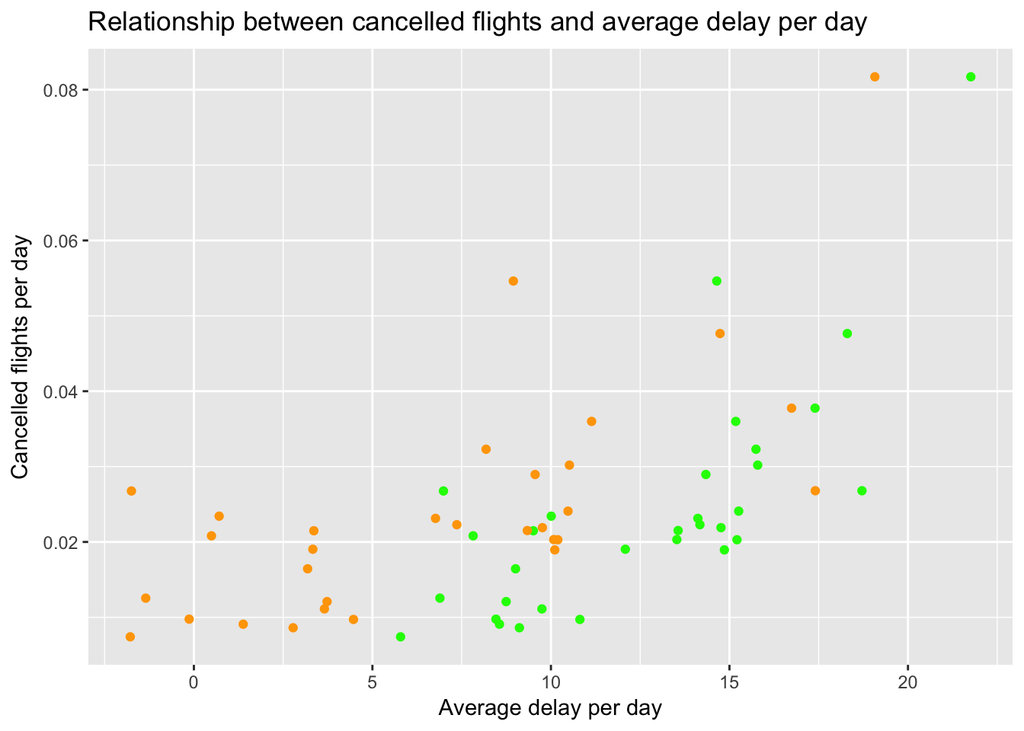

```r
flights %>%
  group_by(day) %>%
  summarise(cancelled = mean(is.na(dep_delay)),
            mean_dep = mean(dep_delay, na.rm = T),
            mean_arr = mean(arr_delay, na.rm = T)) %>%
  ggplot(aes(y = cancelled)) +
  geom_point(aes(x = mean_dep), colour = "green") +
  geom_point(aes(x = mean_arr), colour = "orange") +
  ggtitle("Relationship between cancelled flights and average delay per day")+
  labs(x = "Average delay per day", y = "Cancelled flights per day")
```

Yes, there is a positive relationship between the number of cancelled flights and the average delay per day.

**7. Calculate average delays by carrier. Create a variable which ranks carriers from worst to best, where 1 is the worst rank.**

```r
delayed_carriers<- flights %>%
  group_by(carrier) %>%
  summarise(avg_delay = mean(arr_delay, na.rm = TRUE))%>%
  mutate(rank=rank(desc(avg_delay)))
  arrange(delayed_carriers, rank)
```

```
## # A tibble: 16 x 3
##    carrier  avg_delay  rank
##      <chr>      <dbl> <dbl>
##  1      F9 21.9207048     1
##  2      FL 20.1159055     2
##  3      EV 15.7964311     3
##  4      YV 15.5569853     4
##  5      OO 11.9310345     5
##  6      MQ 10.7747334     6
##  7      WN  9.6491199     7
##  8      B6  9.4579733     8
##  9      9E  7.3796692     9
## 10      UA  3.5580111    10
## 11      US  2.1295951    11
## 12      VX  1.7644644    12
## 13      DL  1.6443409    13
## 14      AA  0.3642909    14
## 15      HA -6.9152047    15
## 16      AS -9.9308886    16
```

**8. Calculate average delays by destination for flights originating in NYC. Create a variable which ranks destinations from worst to best, where 1 is the worst rank.**

```r
delayed_dest<- flights %>%
  group_by(dest) %>%
  summarise(avg_delay = mean(arr_delay, na.rm = TRUE))%>%
  mutate(rank=rank(desc(avg_delay)))
  arrange(delayed_dest, rank)
```

```
## # A tibble: 105 x 3
##     dest avg_delay  rank
##    <chr>     <dbl> <dbl>
##  1   CAE  41.76415     1
##  2   TUL  33.65986     2
##  3   OKC  30.61905     3
##  4   JAC  28.09524     4
##  5   TYS  24.06920     5
##  6   MSN  20.19604     6
##  7   RIC  20.11125     7
##  8   CAK  19.69834     8
##  9   DSM  19.00574     9
## 10   GRR  18.18956    10
## # ... with 95 more rows
```

## 1.3 Section 5.7.1

**1. Which plane (tailnum) has the most minutes of delays total? How many planes are delayed every time they appear in the dataset?**

```r
(delayed_flights <-group_by(flights, tailnum) %>%
summarise(total_arr_delay = sum(arr_delay, na.rm=TRUE), flights_ = n()) %>%
arrange(desc(total_arr_delay)))
```

```
## # A tibble: 4,044 x 3
##    tailnum total_arr_delay flights_
##      <chr>           <dbl>    <int>
##  1  N15910            7317      280
##  2  N15980            7134      316
##  3  N16919            6904      251
##  4  N228JB            6778      388
##  5  N14998            6087      230
##  6  N192JB            5810      319
##  7  N292JB            5804      322
##  8  N12921            5788      280
##  9  N13958            5620      259
## 10  N10575            5566      289
## # ... with 4,034 more rows
```

**2. What time of day should you fly if you want to avoid delays as much as possible?**

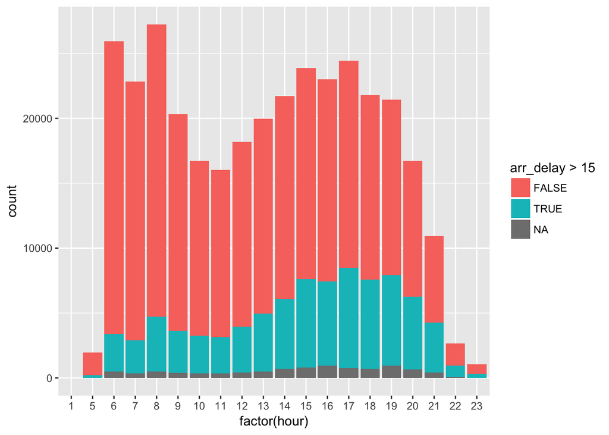

```r
flights %>%
    ggplot(aes(x=factor(hour), fill=arr_delay>15)) + geom_bar()
```

**3. For each destination, compute the total minutes of delay. For each, flight, compute the proportion of the total delay for its destination.**

```r
flights %>%
  group_by(dest) %>%
  filter(!is.na(dep_delay)) %>%
  summarise(tot_mins_delay = sum(dep_delay[dep_delay > 0]))
```

```
## # A tibble: 104 x 2
##     dest tot_mins_delay
##    <chr>          <dbl>
##  1   ABQ           4076
##  2   ACK           2603
##  3   ALB          10934
##  4   ANC            105
##  5   ATL         254414
##  6   AUS          36623
##  7   AVL           3092
##  8   BDL           8471
##  9   BGR           8170
## 10   BHM           8817
## # ... with 94 more rows
```

```r
flights %>%
  filter(!is.na(dep_delay)) %>%
  group_by(tailnum, dest) %>%
  summarise(prop = sum(dep_delay > 0)/sum(dep_delay[dep_delay > 0]), number = n()) %>%
  arrange(desc(prop))
```

```
## # A tibble: 44,218 x 4
## # Groups:   tailnum [4,037]
##    tailnum  dest  prop number
##      <chr> <chr> <dbl>  <int>
##  1  N10156   JAX     1      2
##  2  N11107   MEM     1      2
##  3  N11127   ATL     1      2
##  4  N11137   JAX     1      3
##  5  N11150   GSO     1      4
##  6  N11155   BUF     1      2
##  7  N11164   BTV     1      3
##  8  N11181   CLT     1      2
##  9  N11199   SDF     1      1
## 10  N11536   CAE     1      1
## # ... with 44,208 more rows
```

**4. Delays are typically temporally correlated: even once the problem that caused the initial delay has been resolved, later flights are delayed to allow earlier flights to leave. Use lag() to explore how the delay of a flight is related to the delay of the immediately preceding scheduled flight. Make a plot which shows the relationship between a flight’s delay and the delay of the immediately preceding scheduled flight. You have a lot of data, so think carefully about how to develop a plot which is not too cluttered.**

Yes, those variables are correlated. As we can observe in a simple lm regression, we have that if the previous flight was delayed, the departure delay of the current flight increases (and it is statistically significant).

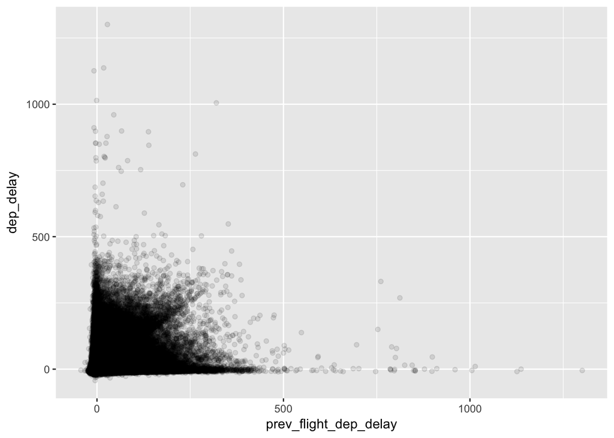

```r
flights %>%
  mutate(new_sched_dep_time = lubridate::make_datetime(year, month, day, hour, minute)) %>%
  group_by(origin) %>%
  arrange(new_sched_dep_time) %>%
  mutate(prev_flight_dep_delay = lag(dep_delay)) %>%
  ggplot(aes(x=prev_flight_dep_delay, y= dep_delay), na.omit()) + geom_point(alpha = 1/10)
```

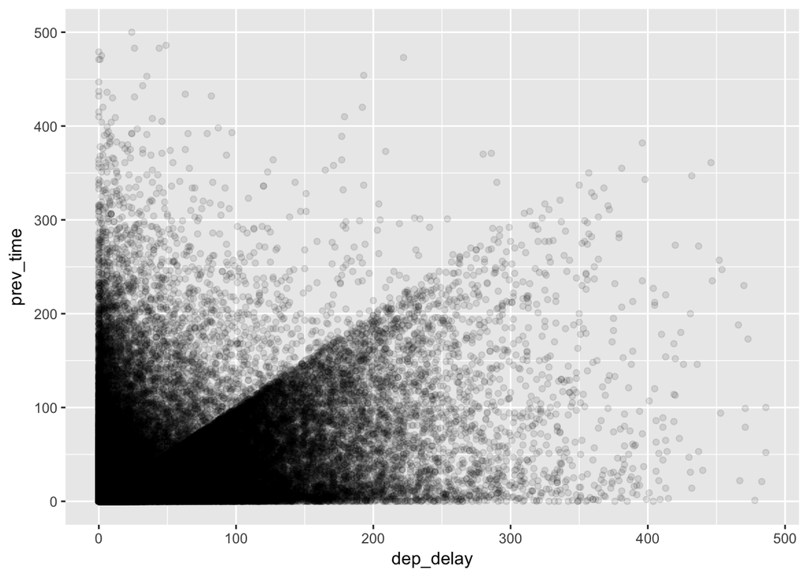

```r
flights %>% #doing a zoom to the values lower than 500, where the data is concentrated
  mutate(new_sched_dep_time = lubridate::make_datetime(year, month, day, hour, minute)) %>%
  arrange(new_sched_dep_time) %>%
  mutate(prev_time = lag(dep_delay)) %>%
  filter(between(dep_delay, 0, 500), between(prev_time, 0, 500)) %>%
  select(origin, new_sched_dep_time, dep_delay, prev_time) %>%
  ggplot(aes(dep_delay, prev_time)) + geom_point(alpha = 1/10)
```

```r
flights %>%
  mutate(new_sched_dep_time = lubridate::make_datetime(year, month, day, hour, minute)) %>%
  group_by(origin) %>%
  arrange(new_sched_dep_time) %>%
  mutate(prev_flight_dep_delay = lag(dep_delay)) %>%
  lm(dep_delay ~ prev_flight_dep_delay,.) %>% summary()
```

```
##
## Call:
## lm(formula = dep_delay ~ prev_flight_dep_delay, data = .)
##
## Residuals:
##     Min      1Q  Median      3Q     Max
## -356.11  -14.51  -10.51   -0.57 1284.55
##
## Coefficients:
##                       Estimate Std. Error t value Pr(>|t|)
## (Intercept)           9.091809   0.069862   130.1   <2e-16 ***
## prev_flight_dep_delay 0.262887   0.001728   152.1   <2e-16 ***
## ---
## Signif. codes:  0 '***' 0.001 '**' 0.01 '*' 0.05 '.' 0.1 ' ' 1
##
## Residual standard error: 37.94 on 322391 degrees of freedom
##   (14383 observations deleted due to missingness)
## Multiple R-squared:  0.06696,    Adjusted R-squared:  0.06695
## F-statistic: 2.314e+04 on 1 and 322391 DF,  p-value: < 2.2e-16
```

**5. Look at each destination. Can you find flights that are suspiciously fast? (i.e. flights that represent a potential data entry error). Compute the air time a flight relative to the shortest flight to that destination. Which flights were most delayed in the air?**

We can observe the minimum, mean and maximum air time by origin and destinations. For routes that are covered by two or more flights, we have that the shortest air time relative to its mean, is a flight between LGA and BOS, that was 21 min instead of 37.8 (mean). On the contrary, the longest flight relative to its mean was a flight from JFK to ACK that lasted 141 min instead of 42 (mean).

There is no hard evidence that there are some flights that are suspiciously fast.

```r
flights %>%
  group_by(origin, dest) %>%
  summarise(mean_time = mean(air_time, na.rm=TRUE),
            min_time=min(air_time, na.rm = TRUE), max_time=max(air_time, na.rm=TRUE),
            shortest=(mean_time-min_time)/mean_time,
            longest=(max_time-mean_time)/mean_time,
            n=n())%>%
  arrange(-longest) %>%
  filter(n>1) %>%
  select(origin, dest, mean_time, min_time, max_time, shortest, longest, n)
```

```
## # A tibble: 219 x 8
## # Groups:   origin [3]
##    origin  dest mean_time min_time max_time  shortest  longest     n
##     <chr> <chr>     <dbl>    <dbl>    <dbl>     <dbl>    <dbl> <int>
##  1    JFK   ACK  42.06818       35      141 0.1680173 2.351702   265
##  2    LGA   DCA  45.59467       32      131 0.2981636 1.873143  4716
##  3    LGA   BOS  37.85082       21      107 0.4451904 1.826887  4283
##  4    EWR   BOS  40.31275       30      112 0.2558186 1.778277  5327
##  5    JFK   BOS  38.48121       26       96 0.3243455 1.494724  5898
##  6    EWR   BDL  25.46602       20       56 0.2146397 1.199009   443
##  7    JFK   SYR  44.53406       35       97 0.2140846 1.178108  1311
##  8    LGA   PHL  37.02676       26       75 0.2978051 1.025562   607
##  9    JFK   DCA  47.89337       34       97 0.2900896 1.025333  3270
## 10    LGA   DTW  84.21333       66      170 0.2162760 1.018683  5040
## # ... with 209 more rows
```

```r
flights %>% group_by(dest) %>%
  mutate(relative_delay =arr_delay - mean(arr_delay)) %>%
  select(flight, dest, arr_delay, relative_delay)
```

```
## # A tibble: 336,776 x 4
## # Groups:   dest [105]
##    flight  dest arr_delay relative_delay
##     <int> <chr>     <dbl>          <dbl>
##  1   1545   IAH        11             NA
##  2   1714   IAH        20             NA
##  3   1141   MIA        33             NA
##  4    725   BQN       -18             NA
##  5    461   ATL       -25             NA
##  6   1696   ORD        12             NA
##  7    507   FLL        19             NA
##  8   5708   IAD       -14             NA
##  9     79   MCO        -8             NA
## 10    301   ORD         8             NA
## # ... with 336,766 more rows
```

**6. Find all destinations that are flown by at least two carriers.**

```r
flights %>%
  group_by(dest) %>%
  filter(n_distinct(carrier)>=2) %>%
  summarise(n = n_distinct(carrier)) %>%
  arrange(-n)
```

```
## # A tibble: 76 x 2
##     dest     n
##    <chr> <int>
##  1   ATL     7
##  2   BOS     7
##  3   CLT     7
##  4   ORD     7
##  5   TPA     7
##  6   AUS     6
##  7   DCA     6
##  8   DTW     6
##  9   IAD     6
## 10   MSP     6
## # ... with 66 more rows
```

**7. For each plane, count the number of flights before the first delay of greater than 1 hour.**

```r
flights %>%
    mutate(dep_date = lubridate::make_datetime(year, month, day)) %>%
    group_by(tailnum) %>%
    arrange(dep_date) %>%
    filter(!cumany(arr_delay>60)) %>%
    tally(sort = TRUE)
```

```
## # A tibble: 3,748 x 2
##    tailnum     n
##      <chr> <int>
##  1  N705TW    97
##  2  N765US    97
##  3  N12125    94
##  4  N320AA    94
##  5  N13110    91
##  6  N3763D    82
##  7  N58101    82
##  8  N17122    81
##  9  N961UW    80
## 10  N950UW    79
## # ... with 3,738 more rows
```

## 1.4 Section 7.3 and 7.4

```r
library(ggplot2)
```

7.3

**1. Explore the distribution of price. Do you discover anything unusual or surprising? (Hint: Carefully think about the binwidth and make sure you try a wide range of values.)**

The distribution shows that there are less diamonds for higher prices, which is what is expected (more expensive diamonds are more exclusive and rare). What is unusual, is that there are gaps in the data (for some prices, there are no diamonds)

```r
diamonds %>% summarise(min(price), max(price), mean(price), mode(price), median(price))
```

```
## # A tibble: 1 x 5
##   `min(price)` `max(price)` `mean(price)` `mode(price)` `median(price)`
##          <dbl>        <dbl>         <dbl>         <chr>           <dbl>
## 1          326        18823        3932.8       numeric            2401
```

```r
group_by(diamonds, price)%>%
  summarise(n=n())%>%
arrange(price)
```

```
## # A tibble: 11,602 x 2
##    price     n
##    <int> <int>
##  1   326     2
##  2   327     1
##  3   334     1
##  4   335     1
##  5   336     2
##  6   337     2
##  7   338     1
##  8   339     1
##  9   340     1
## 10   342     1
## # ... with 11,592 more rows
```

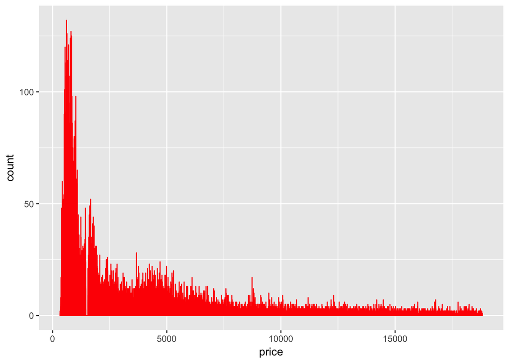

```r
ggplot(diamonds, aes(x = price), xlim=c(0,5000))+geom_histogram(colour="red", binwidth=0.5)
```

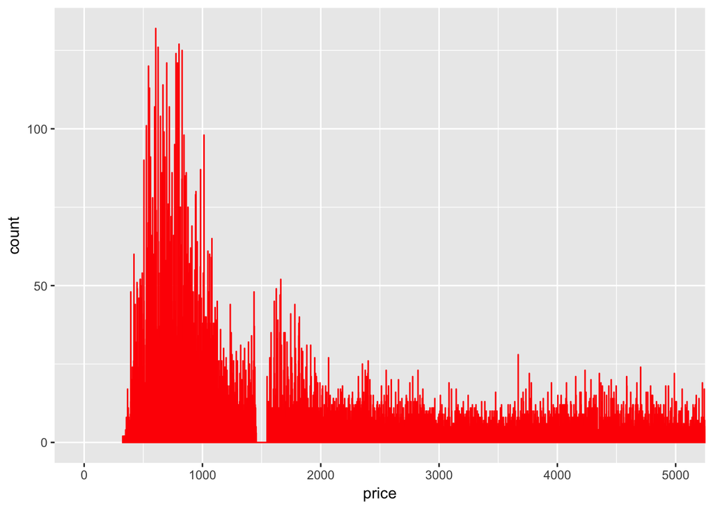

```r
ggplot(diamonds, aes(x = price), xlim=c(0,5000))+geom_histogram(colour="red", binwidth=0.5)+
  coord_cartesian(xlim = c(0, 5000))
```

**2. How many diamonds are 0.99 carat? How many are 1 carat? What do you think is the cause of the difference?**

There are 23 diamonds that are 0.99 carat and 1,558 that are 1 carat. It can be that most of the times the carat is rounded to 1 if its 0.99 but some people are more exact and put 0.99.

```r
diamonds %>%
  filter(carat %in% c(0.99, 1)) %>%
  count(carat)
```

```
## # A tibble: 2 x 2
##   carat     n
##   <dbl> <int>
## 1  0.99    23
## 2  1.00  1558
```

**3. Compare and contrast coord_cartesian() vs xlim() or ylim() when zooming in on a histogram. What happens if you leave binwidth unset? What happens if you try and zoom so only half a bar shows?**

coord_cartesian() refers to the cartesian coordinates, and it allows to set limits on the coordinate system to zoom in the plot. However, it doesn’t change the underlying data like setting limits on a scale will. Source: http://ggplot2.tidyverse.org/reference/coord_cartesian.html

In particular, setting the limits on a scale converts all values outside the range to NA: using xlim() and y(lim) throws away the data outside the limits. Here, the zero is not included.

If the binwidth is unset, `stat_bin()` picks the value. If you try and zoom only half a bar shows, it cut the bar by half (you could use expand=FALSE to turn off expansion with the default limits).

Using xlim delets observations at 0, while coord_cartesian doesn’t.

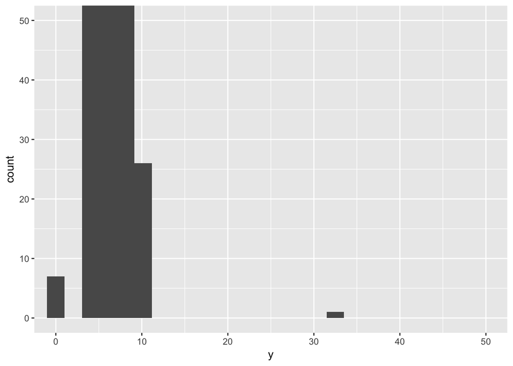

```r
diamonds %>%
  ggplot(aes(y)) +
  geom_histogram() +
  coord_cartesian(xlim =c(0,50), ylim=c(0,50))
```

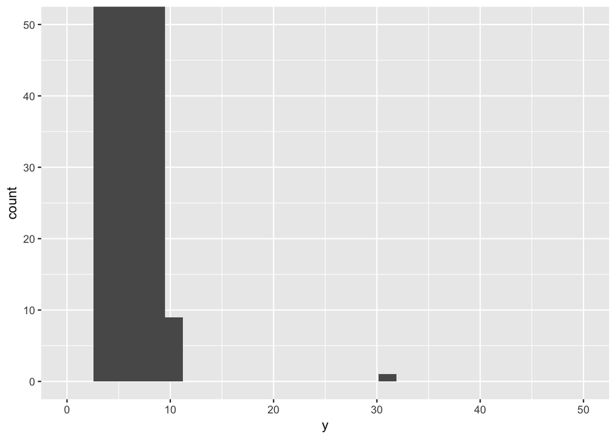

```r
diamonds %>%
  ggplot(aes(y)) +
  geom_histogram() +
  xlim(c(0, 50)) +
  coord_cartesian(y = c(0, 50))
```

7.4

**1. What happens to missing values in a histogram? What happens to missing values in a bar chart? Why is there a difference?**

As we discovered before, the data shows some gaps with the histogram. This was caused by the missing values.

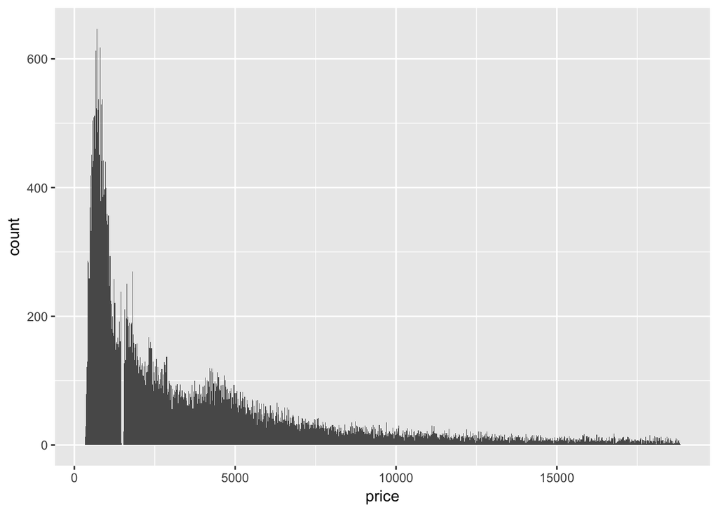

```r
diamonds %>%
  ggplot(aes(price)) +
  geom_histogram(bins = 1000)
```

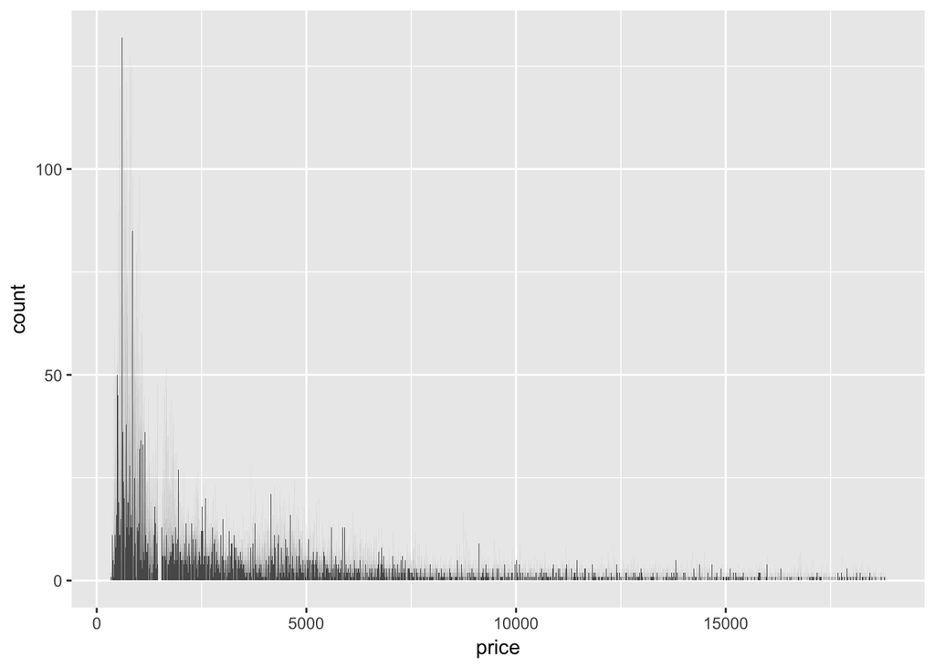

```r
diamonds %>%
  ggplot(aes(price)) +
  geom_bar(bins = 1000)
```

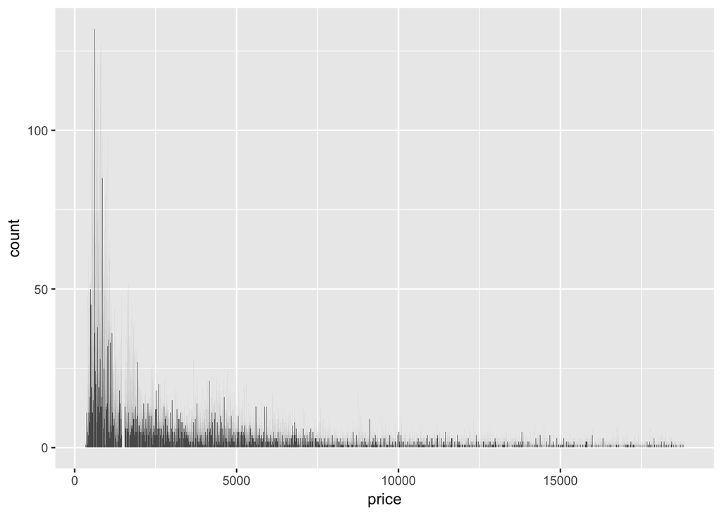

```r
diamonds %>%
ggplot(aes(price)) +
  geom_bar(na.rm = TRUE)
```

**2. What does na.rm = TRUE do in mean() and sum()?**

We know that sum() returns the sum of all the values present in its arguments. The default for this function is na.rm=FALSE. If na.rm is TRUE an NA or NaN value in any of the arguments will be ignored. The same happens to mean().

## 1.5 Section 7.5.2.1

Question: How does seasonality in delays vary by place?

1. First pass: make a data frame with average delay by destination and by month of the year. Use geom_tile() to make a plot of this data frame. What makes the plot difficult to read? (List as many issues as possible.)

This plot has too many tiles (to many destinations) so it is hard to read. The y-axis’ text marks are one over the other. The other problem is that if we want to test seasonality variations by place, we should group different airports by their state or region (midwest airports in winter will have more delays than average, etc)

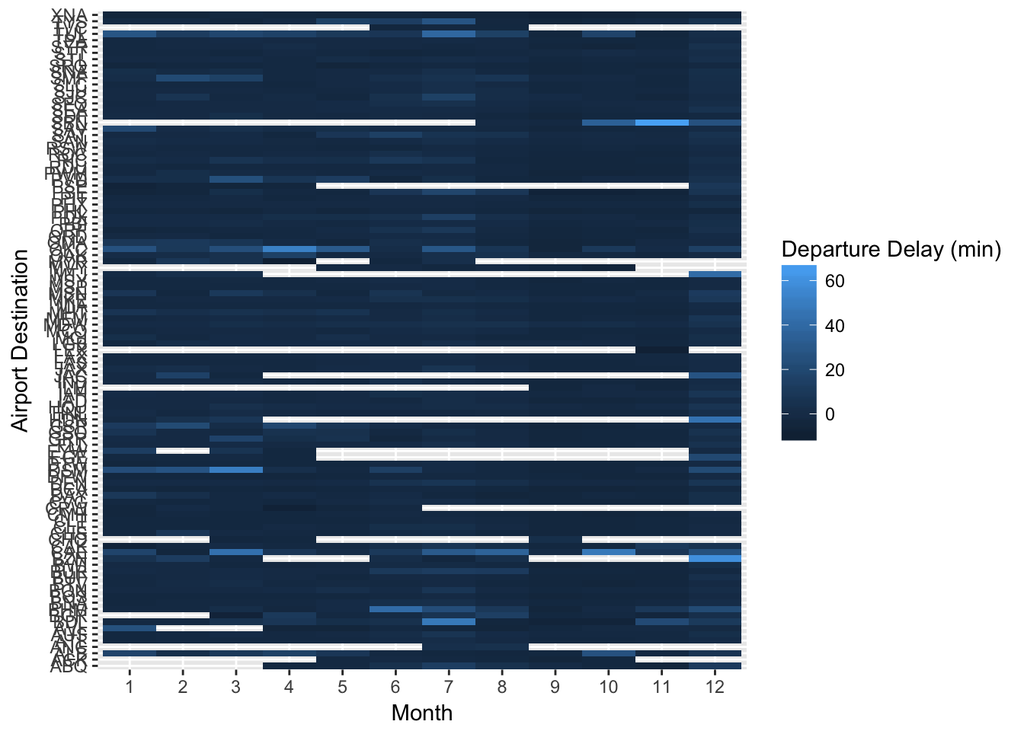

```r
flights %>%
  group_by(dest, month) %>%
  filter(!is.na(dep_delay)) %>%
  mutate(med_delay = median(dep_delay)) %>%
  ggplot(aes(x = as.factor(month), y = dest, fill = med_delay)) +
  geom_tile()+
    labs(x = "Month", y = "Airport Destination", fill = "Departure Delay (min)")
```

2. Make a new plot which resolves at least one (and ideally all) of the issues that you raised, but still answers the broad question “How does seasonality in delays vary by place?” One thing you should be sure to do is develop a strategy for limiting the number of categories on the y-axis to 20.

```r
delayed_dest<- flights %>%
  group_by(dest) %>%
  summarise(avg_delay = mean(arr_delay, na.rm = TRUE))%>%
  mutate(rank=rank(desc(avg_delay)))
  arrange(delayed_dest, rank)
```

```
## # A tibble: 105 x 3
##     dest avg_delay  rank
##    <chr>     <dbl> <dbl>
##  1   CAE  41.76415     1
##  2   TUL  33.65986     2
##  3   OKC  30.61905     3
##  4   JAC  28.09524     4
##  5   TYS  24.06920     5
##  6   MSN  20.19604     6
##  7   RIC  20.11125     7
##  8   CAK  19.69834     8
##  9   DSM  19.00574     9
## 10   GRR  18.18956    10
## # ... with 95 more rows
```

```r
dest_selection <- subset(delayed_dest, rank <= 20)
dest_selection
```

```
## # A tibble: 20 x 3
##     dest avg_delay  rank
##    <chr>     <dbl> <dbl>
##  1   ALB  14.39713    20
##  2   BHM  16.87732    11
##  3   CAE  41.76415     1
##  4   CAK  19.69834     8
##  5   CRW  14.67164    18
##  6   CVG  15.36456    14
##  7   DSM  19.00574     9
##  8   GRR  18.18956    10
##  9   GSP  15.93544    13
## 10   JAC  28.09524     4
## 11   MCI  14.51406    19
## 12   MHT  14.78755    16
## 13   MSN  20.19604     6
## 14   OKC  30.61905     3
## 15   OMA  14.69890    17
## 16   PVD  16.23464    12
## 17   RIC  20.11125     7
## 18   SAV  15.12951    15
## 19   TUL  33.65986     2
## 20   TYS  24.06920     5
```

flights %>% group_by(dest, month) %>% filter(!is.na(dep_delay))%>% subset(dest==“MCI”|“MHT”|“MSN”|“OKC”|“OMA”|“PVD”|“RIC”|“SAV”|“TUL”|“TYS”|“ALB”|“BHM”|“CAE”|“CAK”|“CRW”|“CVG”|“DSM”|“GRR”|“GSP”|“JAC”) %>% mutate(med_delay = median(dep_delay)) %>% ggplot(aes(x = as.factor(month), y = dest, fill = med_delay)) + geom_tile()+ labs(x = “Month”, y = “Airport Destination”, fill = “Departure Delay (min)”)

3. Write out in words the answer to the question. Be sure that these are conclusions that a reader can draw directly from your second plot rather than things you happened to learn along the way.

## 1.6 Public Sector Application: Flight Data

```r
one <- read.csv("flightsIL/1065640122_T_ONTIME.csv")
two <- read.csv("flightsIL/1065640122_T_ONTIME-2.csv")
three <- read.csv("flightsIL/1065640122_T_ONTIME-3.csv")
four <- read.csv("flightsIL/1065640122_T_ONTIME-4.csv")
five <- read.csv("flightsIL/1065640122_T_ONTIME-5.csv")
six <- read.csv("flightsIL/1065640122_T_ONTIME-6.csv")
seven <- read.csv("flightsIL/1065640122_T_ONTIME-7.csv")
eight <- read.csv("flightsIL/1065640122_T_ONTIME-8.csv")
nine <- read.csv("flightsIL/1065640122_T_ONTIME-9.csv")
ten <- read.csv("flightsIL/1065640122_T_ONTIME-10.csv")
eleven <- read.csv("flightsIL/1065640122_T_ONTIME-11.csv")
twelve <- read.csv("flightsIL/1065640122_T_ONTIME-12.csv")

chi.flights <- bind_rows(one, two, three, four, five, six, seven, eight, nine, ten, eleven, twelve)
```

[output not shown]

[output cut: 190 more lines]

[output not shown]

An international trade organization is hosting a two-day convention in Chicago in 2019. The mayor’s tourism office has asked for some planning help based on historical data from 2016. Use the same data which you analyzed for PS1, limiting the sample to flights from Midway and Ohare. For each question, please follow the four-part approach laid out in lecture. I have given you the question (step 1). You should write out your query (step 2), show the plot from this query (step 3), and write out the answer to the question in a sentence (step 4).

```r
(selected_flights<- subset(chi.flights, (chi.flights$DEST_AIRPORT_ID==13930 | chi.flights$DEST_AIRPORT_ID==13232 | chi.flights$ORIGIN_AIRPORT_ID==13930 | chi.flights$ORIGIN_AIRPORT_ID==13232)))
```

[output not shown]

[output cut: 21203 more lines]

```r
library(dplyr)
```

**1. When are average arrival delays (measured using the arrival delay variable) the lowest? When are are least 80% of flights on-time? Make a single plot that answers both questions and write a sentence (or two) that answers these questions.**

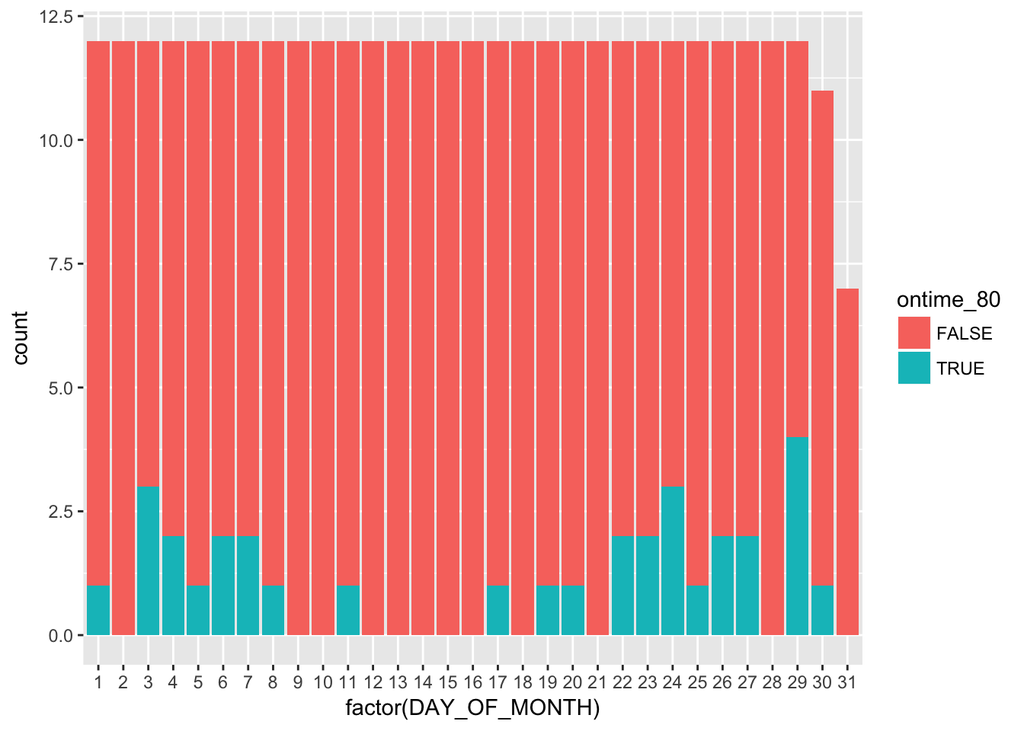

```r
arrival_delays <- selected_flights %>%
  group_by(MONTH, DAY_OF_MONTH)%>%
  summarise(av_delay = mean(ARR_DELAY, na.rm = TRUE),
            ontime = mean(ARR_DELAY <= 0, na.rm = TRUE),
            lowest = min(av_delay)) %>%
  mutate(ontime_80 = ontime > 0.8) %>%
  arrange(av_delay)

ggplot(arrival_delays, aes(x = factor(DAY_OF_MONTH), fill = ontime_80)) +
  geom_bar()
```

**2. When are flights to Chicago most common? Make a plot to support your answer and write a sentence to answer the question.**

```r
flights_to_CHI <- selected_flights %>%
  filter(DEST_CITY_NAME == "Chicago, IL") %>%
  group_by(MONTH) %>%
  summarise(n_flights = n()) %>%
  arrange(desc(n_flights))

flights_to_CHI
```

```
## # A tibble: 12 x 2
##    MONTH n_flights
##    <int>     <int>
##  1     7     30346
##  2     8     30074
##  3     6     29577
##  4     5     29125
##  5    10     29023
##  6     9     27675
##  7     3     27243
##  8     4     27108
##  9    11     26349
## 10    12     25944
## 11     1     25281
## 12     2     23946
```

**3. What date do you recommend they have the convention? Take into account both the number of flights to Chicago and that people would like to arrive in Chicago on-time and not get delayed on the way in (don’t worry about delays on the way home). Why did you recommend this date? Write a few sentences.**

```r
selected_flights %>%
  group_by(MONTH, DAY_OF_MONTH) %>%
  filter(rank(desc(ARR_DELAY)), DEST_CITY_NAME == "Chicago, IL" )%>%
  summarize(no_flights = n(),
            av_delay = mean(ARR_DELAY, na.rm = TRUE))%>%
  arrange(av_delay)
```

```
## # A tibble: 366 x 4
## # Groups:   MONTH [12]
##    MONTH DAY_OF_MONTH no_flights  av_delay
##    <int>        <int>      <int>     <dbl>
##  1     1           30        641 -15.67293
##  2     2           20        679 -14.80741
##  3    11           24        514 -14.53113
##  4     2            1        862 -14.45991
##  5     2            7        686 -13.41752
##  6     5           29        755 -12.90969
##  7     2           27        680 -12.74298
##  8     2            6        638 -11.58176
##  9     9            4        737 -11.56871
## 10     9            3        674 -11.38187
## # ... with 356 more rows
```

1. In lecture, we covered the idea of “basic” plots and “sophisticated” plots. Make a “basic” plot which provides just the minimal amount of information needed to support your written recommendation.

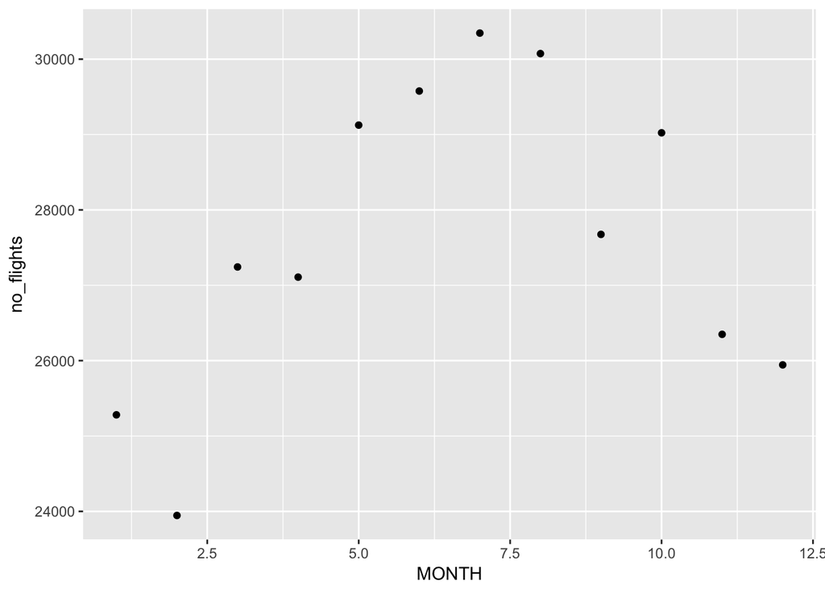

```r
#basic plot
flights_to_chicago <- selected_flights %>%
  filter(DEST_CITY_NAME == "Chicago, IL") %>%
  group_by(MONTH) %>%
  summarise(no_flights = n()) %>%
  arrange(desc(no_flights))

  ggplot(flights_to_chicago, aes(x = MONTH, y = no_flights)) +
  geom_point()
```

2. Make a “sophisticated” plot as well that contains more information about flight delays. What are the sub-messages in the “sophisticated” plots that are not in the “basic” plot? If you could submit only one of the two plots to the mayor’s office, which would you submit and why?

The more sophisticated include more information. If they are well constructed, they are preferred to basic plots.

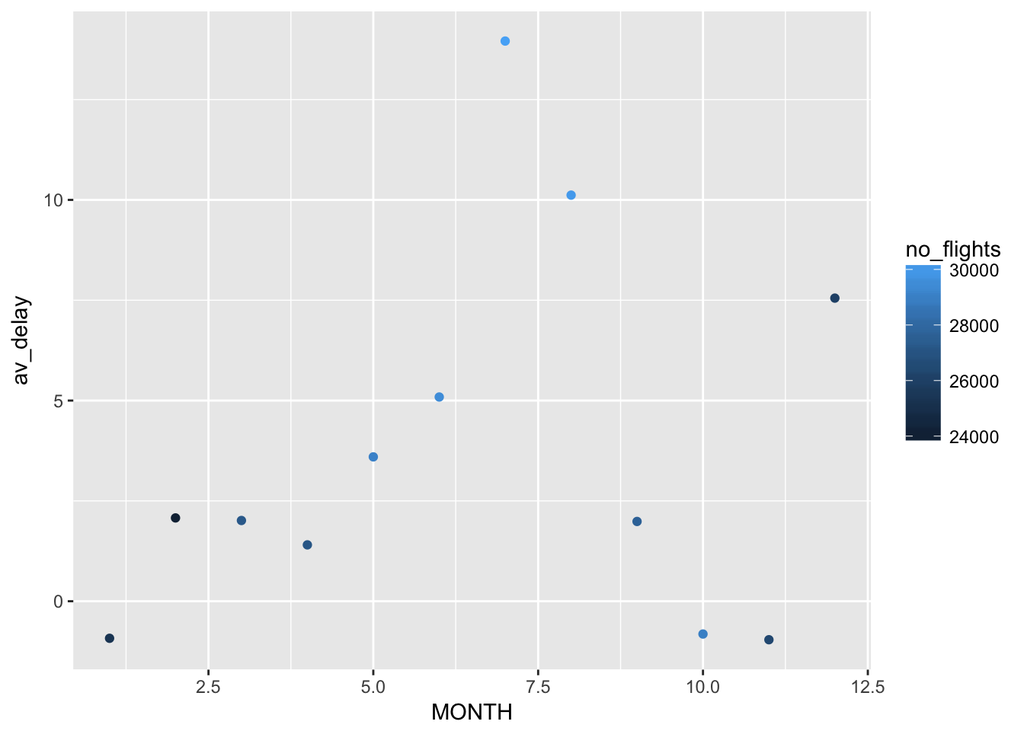

```r
best_date <- selected_flights %>%
  filter(DEST_CITY_NAME == "Chicago, IL") %>%
  group_by(MONTH) %>%
  summarise(no_flights = n(),
            av_delay = mean(ARR_DELAY, na.rm = TRUE)) #%>%

  ggplot(best_date, aes(x = MONTH, y = av_delay, color= no_flights)) +
  geom_point()
```

[output not shown]